# PIT Scanner Diagnostics — Imperial Ponds Bonytail (Ponds 2, 5, 6)

Monthly scanning effort, contact rates, and data sufficiency for robust-design modeling

Author

Marsh & Associates

Published

September 4, 2026

## Purpose

This report summarizes passive PIT-scanner effort and tag-contact rates for the three Bonytail (GIEL) ponds at the Imperial Ponds Conservation Area. The goal is to judge, pond by pond, whether the scanning record is dense and consistent enough to support the joint robust-design mark-recapture model, and to show how contact rates relate to season and to the size of the tagged population.

Two things make this non-trivial:

1. **Deployments span months.** A scanner deployed March 15 and retrieved April 15 contributes effort to both March and April. Effort and contacts are therefore split by calendar day and re-aggregated to month, so each month is credited only with the hours actually scanned inside it.
2. **Contact rates are confounded with population size.** A low contact rate can mean fish are inactive (seasonal), that scanners were down, or that few tagged fish remain alive. The plots below separate these by pairing contact rate with effort and with the minimum number of tagged fish known to be alive.

## Methods

### Splitting deployments into monthly effort

Each deployment record in `StudyBWEffort` has a deploy and retrieve timestamp, total deployed hours, and total hours the unit was actually scanning (`ScanTimeHrs`). For each deployment the hours overlapping each calendar day were computed, then scaled by the fraction of deployed time the unit was scanning (`ScanTimeHrs / DeployedHrs`). Daily scan hours were then summed by pond and month. Where multiple units ran simultaneously in a pond, their hours are added, so a month can exceed the number of hours in the month. “Coverage days” counts days in the month with at least one unit scanning, regardless of how many units.

### Contacts and contact rates

Contacts (`StudyBWContacts`, summarized per fish-date-hour) were restricted to PIT tags identified as Bonytail in the NFWG database and to the pond where the contact occurred. Three monthly metrics are reported:

- **Unique fish contacted** — distinct PIT tags detected in the pond that month.
- **Proportion detected** — unique fish contacted divided by the minimum number of tagged fish known alive in that month. A fish is “known alive” in a month if it was tagged in the pond on or before the last day of the month and was contacted in the pond (its last local contact, `MaxScanDate`, which defaults to the tagging date for fish never scanned) on or after the first day of the month. This is deliberately month-scoped rather than the project’s 90-DAL survivor definition so that fish contacted shortly after stocking are in the denominator and the proportion cannot exceed 1. Because a fish is only “known alive” through its last contact, this denominator is biased low in the most recent months, which inflates the proportion near the end of the series.
- **Contacts per 100 scan-hours** — fish-hour contact records divided by monthly scan hours; an effort-standardized detection rate that does not depend on the known-alive denominator.

## Scanning effort over time

Figure 1 shows monthly scan hours (all units combined) with the share of days in each month that had at least one unit running. Months with zero effort are gaps in the record; months with hours but low coverage indicate a unit deployed for only part of the month.

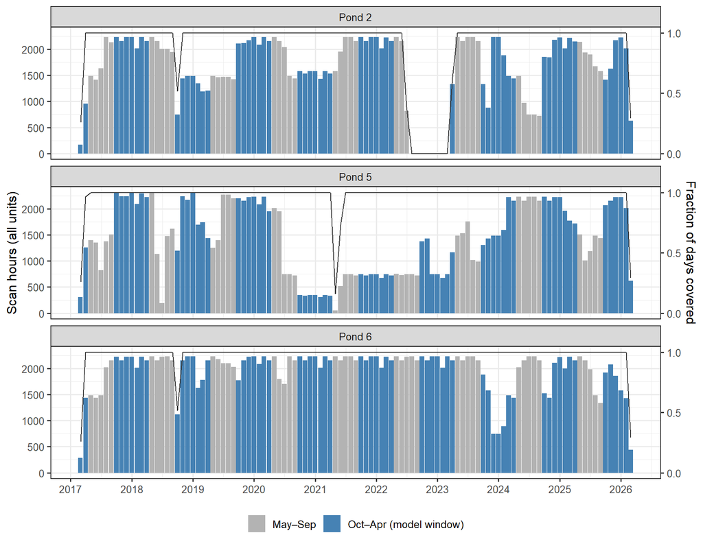

Figure 1: Monthly passive scanning effort by pond. Bars are total scan hours summed across all units; the line is the fraction of days in the month with at least one unit scanning (right axis, scaled to the bar height).

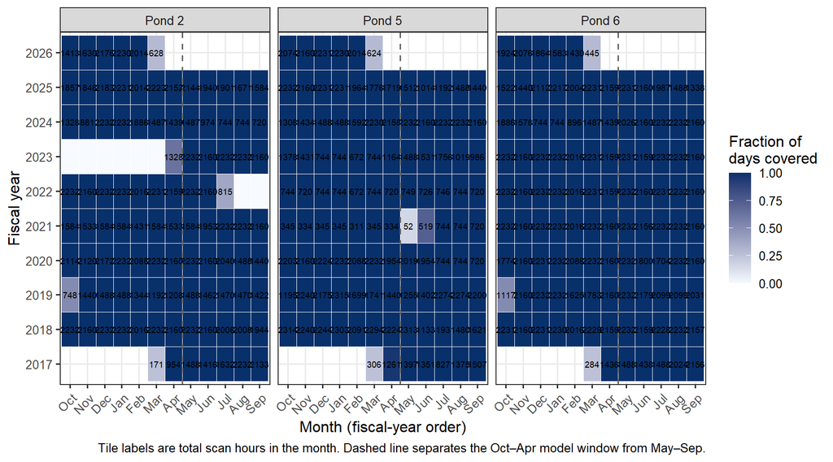

Figure 2: Scan-day coverage by fiscal year and month. Each tile is the fraction of days in that month with at least one scanner running. Blank tiles had no scanning. The robust-design model uses Oct–Apr months as primary periods.

## Contacts, contact rates, and tagged population size

Figure 3 stacks four monthly series per pond: the minimum tagged population known alive, the number of unique tagged fish contacted, the proportion of known-alive fish detected, and the effort-standardized contact rate. Reading down a column makes it possible to distinguish months where few fish were detected because few were alive (known-alive is low) from months where fish were present but not detected (known-alive high, proportion detected low, effort present).

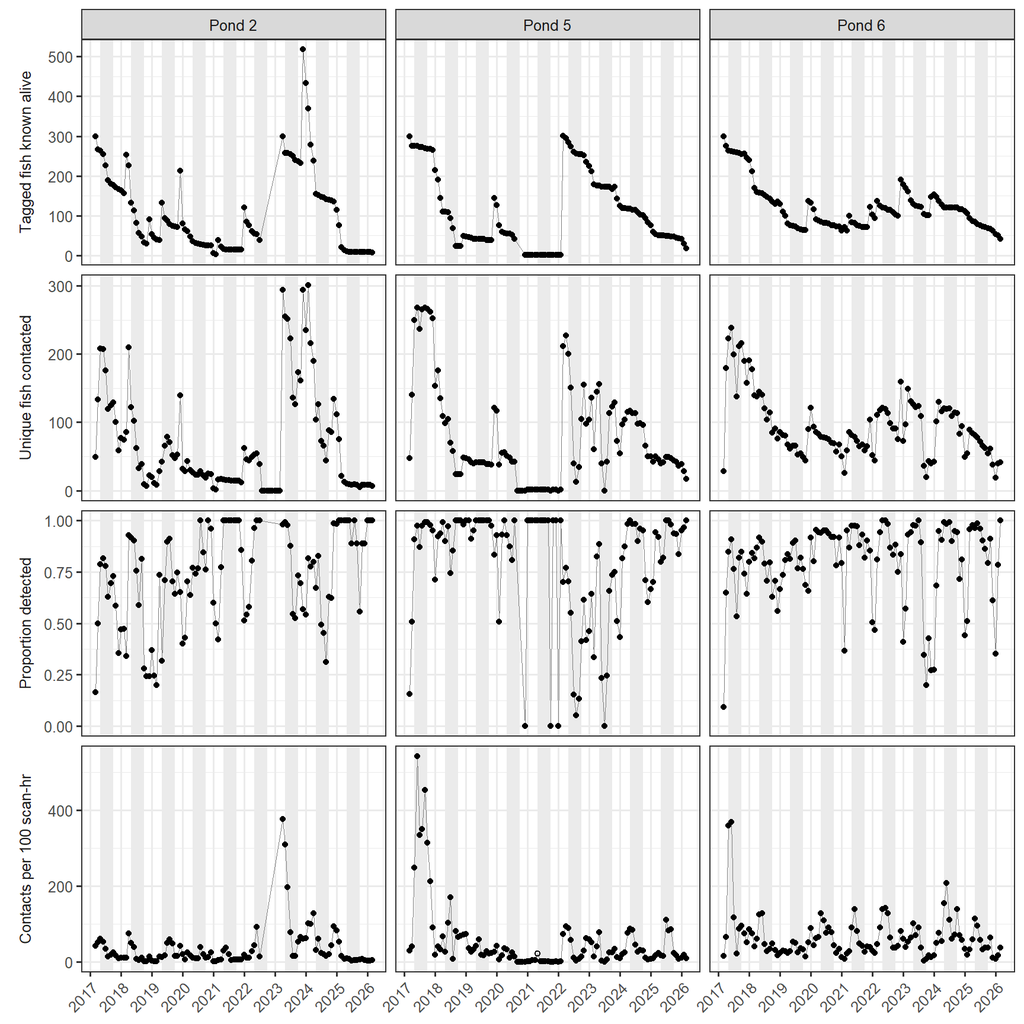

Figure 3: Monthly tagged population and detection metrics by pond. Grey shading marks May–Sep months, which are outside the Oct–Apr model window. Open circles in the effort-standardized rows mark months with fewer than 100 scan hours, where rates are unstable. Proportion detected uses month-scoped known-alive as the denominator and is inflated in the most recent year because ‘known alive’ depends on later contacts.

### Seasonal pattern

Figure 4 pools years to show how detection varies with month of year. Only months with at least 100 scan hours are included so that low proportions reflect fish behaviour rather than scanner downtime.

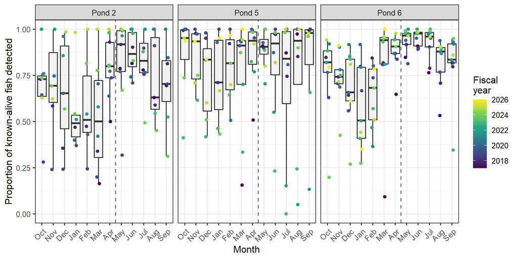

Figure 4: Proportion of known-alive tagged Bonytail detected by calendar month (fiscal-year order), pooled across years. Each point is one pond-month with ≥ 100 scan hours; boxes summarize the distribution across years.

### Contact rate versus tagged population size

If detection probability were constant, unique fish contacted would rise linearly with the number alive and proportion detected would be flat. Figure 5 shows the actual relationship; departures from a flat line indicate that detection probability itself changes with density, season, or year, all of which matter for the model’s detection sub-model.

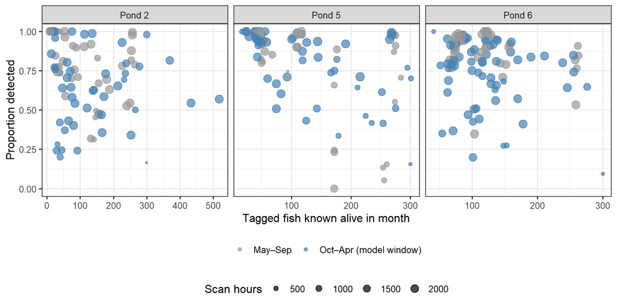

Figure 5: Proportion of known-alive fish detected versus the number known alive, for months with ≥ 100 scan hours. Colour distinguishes the Oct–Apr model window from summer months; point size is scan hours.

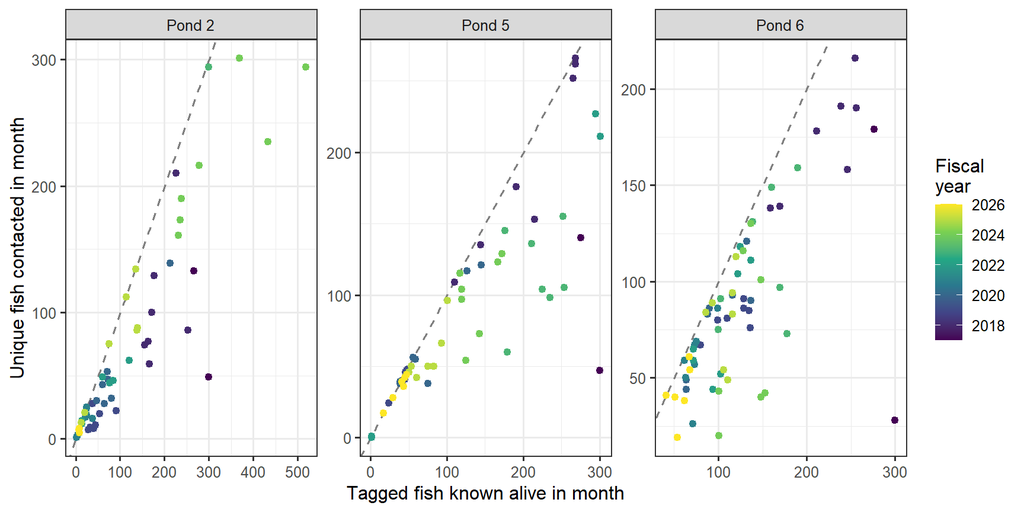

Figure 6: Unique fish contacted versus number known alive, Oct–Apr months with ≥ 100 scan hours only. The dashed line is 1:1 (every known-alive fish detected).

## Data sufficiency for the robust-design model

The model treats each Oct–Apr month (7 per fiscal year) as a primary period with four weekly secondary occasions. A useful month needs scanner effort across most weeks and enough tagged fish alive to yield recaptures. Table 1 summarizes each pond × fiscal year on these criteria.

Table 1: Oct–Apr scanning summary by pond and fiscal year. ‘Months scanned’ counts months with any effort (of 7); ‘Months ≥ 50% cover’ counts months with scanners running on at least half the days; weeks covered counts week-of-month blocks (4 per month, 28 per year) with at least one scan day. Known alive is the range over the seven months; median proportion detected is over months with ≥ 100 scan hours.

| Pond | FY | Months scanned (of 7) | Months ≥ 50% cover | Weeks covered (of 28) | Scan hours | Known alive | Unique fish contacted | Median prop. detected |
| --- | --- | --- | --- | --- | --- | --- | --- | --- |
| Pond 2 | 2017 | 2 | 1 | 5 | 1125 | 266–299 | 144 | 0.33 |
|  | 2018 | 7 | 7 | 28 | 15263 | 156–253 | 248 | 0.47 |
|  | 2019 | 7 | 7 | 26 | 8908 | 29–91 | 62 | 0.24 |
|  | 2020 | 7 | 7 | 28 | 15117 | 47–213 | 161 | 0.64 |
|  | 2021 | 7 | 7 | 28 | 10832 | 2–38 | 47 | 0.76 |
|  | 2022 | 7 | 7 | 28 | 15261 | 14–121 | 99 | 0.80 |
|  | 2023 | 1 | 1 | 3 | 1328 | 300–300 | 294 | 0.98 |
|  | 2024 | 7 | 7 | 28 | 11485 | 232–518 | 489 | 0.73 |
|  | 2025 | 7 | 7 | 28 | 14508 | 13–140 | 140 | 0.99 |
|  | 2026 | 6 | 5 | 22 | 10092 | 7–9 | 9 | 0.94 |
| Pond 5 | 2017 | 2 | 1 | 5 | 1566 | 275–300 | 156 | 0.33 |
|  | 2018 | 7 | 7 | 28 | 15711 | 110–268 | 280 | 0.95 |
|  | 2019 | 7 | 7 | 28 | 12807 | 24–49 | 48 | 1.00 |
|  | 2020 | 7 | 7 | 28 | 15093 | 39–145 | 143 | 0.93 |
|  | 2021 | 7 | 7 | 28 | 2357 | 1–1 | 1 | 1.00 |
|  | 2022 | 7 | 7 | 28 | 5087 | 1–301 | 271 | 0.77 |
|  | 2023 | 7 | 7 | 28 | 6876 | 176–254 | 253 | 0.46 |
|  | 2024 | 7 | 7 | 28 | 11698 | 117–172 | 173 | 0.75 |
|  | 2025 | 7 | 7 | 28 | 14312 | 50–101 | 101 | 0.71 |
|  | 2026 | 6 | 5 | 22 | 11333 | 17–47 | 47 | 0.94 |
| Pond 6 | 2017 | 2 | 1 | 5 | 1720 | 276–300 | 183 | 0.37 |
|  | 2018 | 7 | 7 | 28 | 15255 | 159–256 | 260 | 0.82 |
|  | 2019 | 7 | 7 | 26 | 13308 | 80–136 | 142 | 0.71 |
|  | 2020 | 7 | 7 | 28 | 14876 | 64–137 | 138 | 0.80 |
|  | 2021 | 7 | 7 | 28 | 15264 | 62–99 | 136 | 0.87 |
|  | 2022 | 7 | 7 | 28 | 15261 | 72–137 | 160 | 0.82 |
|  | 2023 | 7 | 7 | 28 | 15262 | 100–190 | 192 | 0.84 |
|  | 2024 | 7 | 7 | 28 | 8774 | 101–153 | 157 | 0.43 |
|  | 2025 | 7 | 7 | 28 | 13685 | 86–120 | 120 | 0.81 |
|  | 2026 | 6 | 5 | 22 | 9322 | 41–68 | 68 | 0.79 |

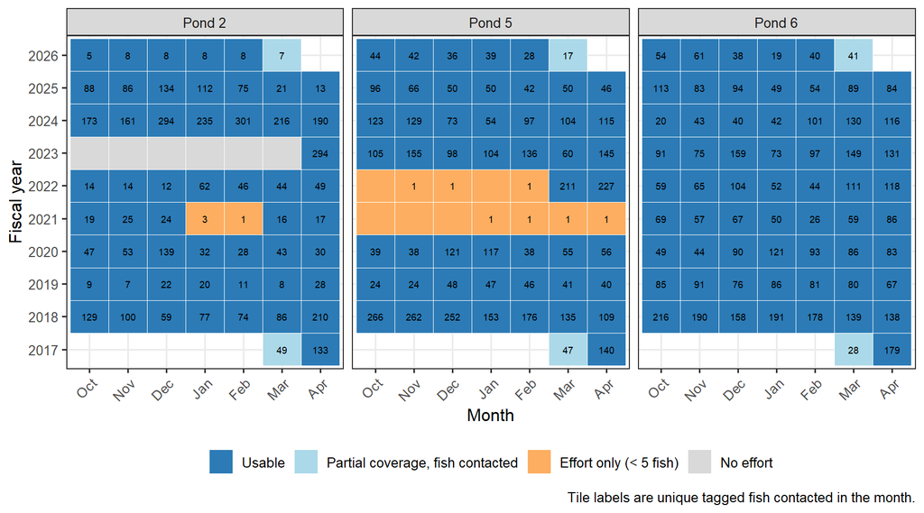

Figure 7: Per-month sufficiency screen for the Oct–Apr model window. A month is classed as ‘usable’ when it has ≥ 50% scan-day coverage and at least 5 unique tagged fish contacted; ‘effort only’ when scanners ran but fewer than 5 fish were contacted; ‘no effort’ otherwise.

## Summary

| Pond | Oct–Apr months (FY2017+) | % with any effort | % with ≥ 50% coverage | % usable (coverage + ≥ 5 fish) | Max known alive |
| --- | --- | --- | --- | --- | --- |
| Pond 2 | 64 | 91 | 88 | 84 | 518 |
| Pond 5 | 64 | 100 | 97 | 78 | 301 |
| Pond 6 | 64 | 100 | 97 | 97 | 300 |

All figures were produced from `data/ReportingData.RData` (`StudyBWEffort`, `StudyBWContacts`, `StudyBWAnalysis`).